# DTEK0042 Exercise 2

```
Group Members:
1. Tristan Deenen
2. Anna Fernandez-Rajal i Sabala
3. Irene Torrijos Robles
```

*Note for Google Colab Users* Because Google Colab doesn't have a button to convert your notebook to .html format here is a quick work around:

1. open a new google colab notebook
2. in the files section in google colab, upload the .ipynb file you want to be converted to .html
3. in your new open notebook run this command in an empty cell: !jupyter nbconvert --to html YourFileName.ipynb
4. after the command is finished running refresh the page
5. In your files section you should see your original .ipynb file that you uploaded and then a .html file of that same notebook.
6. download the .html file and you're good to go!

In this exercise, you are required to analyze an ECG signal step-by-step as outlined below. The deliverables for this exercise are a jupyter notebook in both .ipynb and .html format. Please provide caption for every figure and include description for every figure.

## library Imports

```python
import scipy as sp
import numpy as np
import matplotlib.pyplot as plt
```

```python
from scipy.fft import rfft, rfftfreq
```

```python
import scipy.signal as sg
```

# Data Import and plotting

- Import the ECG signal named “ECG_800Hz.txt” into your python environment and store it in a variable named “ECG_sig”.
- Plot the signal
- Note: the sampling frequency of this signal is 800Hz.
- You need this value if you want to plot ECG versus time.

```
 HINT: ECG_sig = np.loadtxt(the directory of the ECG signal)
 https://numpy.org/doc/stable/reference/generated/numpy.loadtxt.html
```

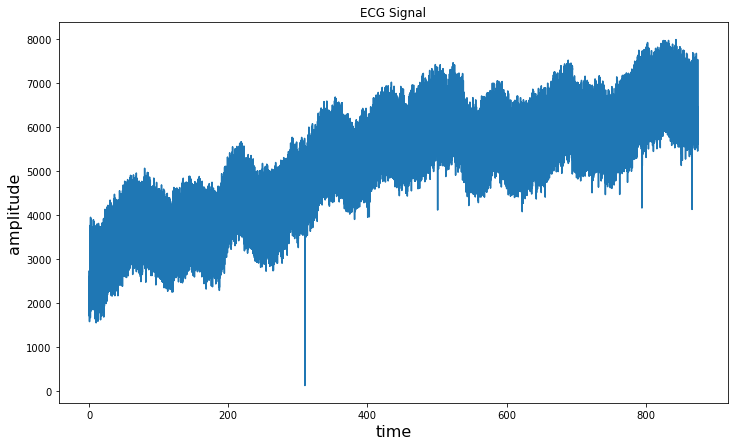

```python
#code
ECG_sig = np.loadtxt('/Users/irenetorrijosrobles/Documents/EIT/UTU/Biosignals/exercises/ECG_800hz.txt')

fs = 800

seconds_time=np.linspace(0,(len(ECG_sig)/fs),len(ECG_sig))


# Plot the whole signal
plt.figure(figsize=(12,7))
plt.plot(seconds_time,ECG_sig)
plt.title("ECG Signal")
plt.xlabel("time",fontsize=16)
plt.ylabel("amplitude",fontsize=16)
plt.show()
```

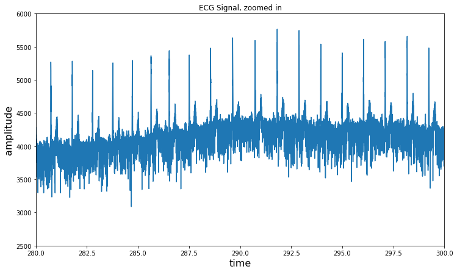

```python
# Zoome in the signal
plt.figure(figsize=(12,7))
plt.plot(seconds_time,ECG_sig)
plt.title("ECG Signal, zoomed in")
plt.xlabel("time",fontsize=16)
plt.ylabel("amplitude",fontsize=16)
plt.xlim(280,300)
plt.ylim(2500,6000)
plt.show()
```

# Discrete Fourier Transform

- Compute DFT using FFT algorithm provided by scipy package. Take only the positive frequencies from the computed DFT and subsequently calculate the magnitude (absolute value) of frequency content. Plot the calculated magnitude versus frequency.
- Discard the frequencies below 0.5Hz and above 40Hz and replot the magnitude versus frequency.

```
 * HINT use scipy.fft.rfft() outputs positive portion of function

 https://docs.scipy.org/doc/scipy/reference/generated/scipy.fft.rfft.html
 https://docs.scipy.org/doc/scipy/reference/generated/scipy.fft.rfftfreq.html
```

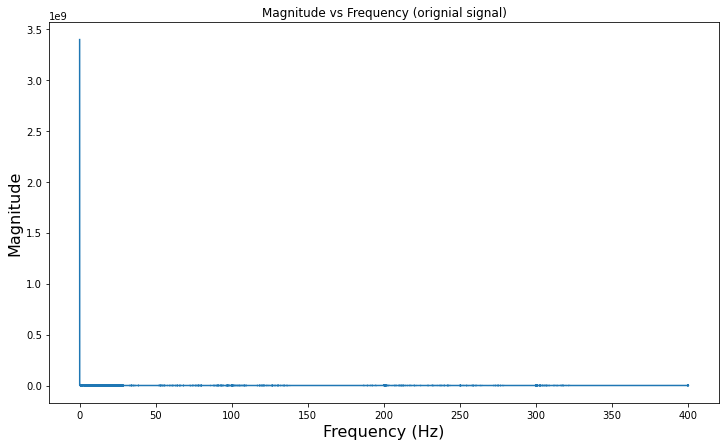

```python
fs = 800

# DFT of the signal
dft = rfft(ECG_sig)

# Freq values from the DFT
freqs = rfftfreq(len(ECG_sig), 1 / fs)

# Plot the DFT of the signal
plt.figure(figsize=(12, 7))
plt.plot(freqs, np.abs(dft))
plt.title("Magnitude vs Frequency (orignial signal)")
plt.xlabel("Frequency (Hz)", fontsize=16)
plt.ylabel("Magnitude", fontsize=16)
plt.show()
```

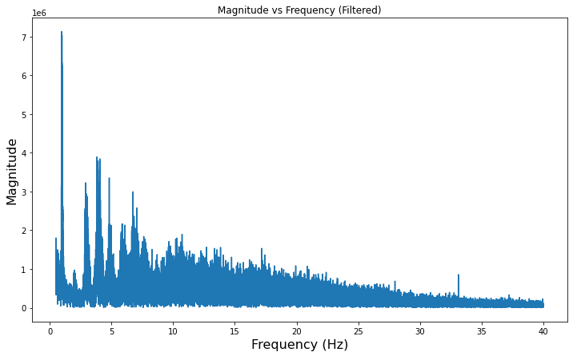

```python
# Discard freqs below 0.5Hz and above 40Hz
mask = (freqs > 0.5 ) & (freqs < 40)

filtered_dft = dft[mask]
filtered_freqs = freqs[mask]

# plot filtered ECG
plt.figure(figsize=(12, 7))
plt.plot(filtered_freqs, np.abs(filtered_dft))
plt.title("Magnitude vs Frequency (Filtered)")
plt.xlabel("Frequency (Hz)", fontsize=16)
plt.ylabel("Magnitude", fontsize=16)
plt.show()
```

# Band Pass Filter Design

- Design a band pass filter. Use Butterworth filter of order 4 with cutoff frequencies equal to 0.5Hz and 40Hz.
- Design another butterworth band pass filter but this time use an order of 2 with cutoff frequencies equal to 0.5Hz and 40Hz
- Plot the frequency response of both filters and explain your observations

```
* Hint use the following three functions scipy.signal.butter() and scipy.signal.freqz()
```

- Important to use the scipy.signal.freqz() function and NOT the scipy.signal.freqs() function.

  ```
    scipy.signal.freqz() is for digital filters which is what we want.
  ```

https://docs.scipy.org/doc/scipy/reference/signal.html#filtering link to info about scipy.signal functions

```python
# Filter order 4
b4, a4 = sg.butter(4, Wn = (0.5, 40), btype='bandpass', fs = fs)

# Filter order 2
b2, a2 = sg.butter(2, Wn = (0.5, 40), btype='bandpass', fs = fs)


#Frequency response of the filters
w4, h4 = sg.freqz(b4, a4, worN=8000)
w2, h2 = sg.freqz(b2, a2, worN=8000)
```

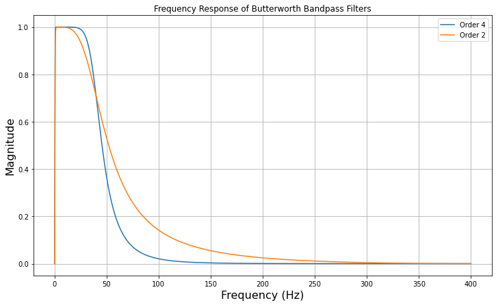

```python
# Plot the frequency response
plt.figure(figsize=(12, 7))
plt.plot(0.5 * fs * w4 / np.pi, np.abs(h4), label=f'Order {4}')
plt.plot(0.5 * fs * w2 / np.pi, np.abs(h2), label=f'Order {2}')
plt.title("Frequency Response of Butterworth Bandpass Filters")
plt.xlabel("Frequency (Hz)", fontsize=16)
plt.ylabel("Magnitude", fontsize=16)
plt.grid(True)
plt.legend()
plt.show()
```

## Observations:

Both filters start at almos 0 (0.5 Hz) and start droping around 40 Hz, the cutoff frequencies that were given. Both filters look estable, which is crucial for a good filtering.

It can be seen that the filters are generally the same, they start at 0.5 and let through up to about 40 Hz, and then turn to 0, which means that no frequencies pass through. However, depending on the order of the filter, the end of the filter is steeper or not. We can see that the higher the filter order the steeper the step, which allows more frequencies near 40 Hz to pass through and frequencies after 40 Hz to be cut off earlier. The ideal filter is the one that has the shape of a perfect rectangle since it cuts the frequencies exactly where we want them. However, as it is almost impossible to achieve it, we want to get one as close as possible, which in this case is the one of order 4.

# Apply filter to ECG_Sig

- Use the designed 4th order filter to filter ECG_sig and plot the first 5000 samples from the original signal (raw_signal) and the filtered signal.
- What happens after filtering?
- Explain your observations

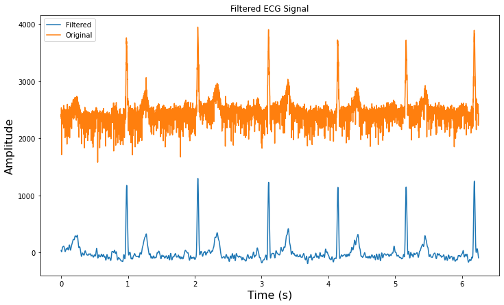

```python
# Use the order 4 filter to the signal ECG_sig
filtered_ecg4 = sg.filtfilt(b4, a4, ECG_sig)

# Plot the first 5000 samples of the filtered signal and the original signal
plt.figure(figsize=(12, 7))
plt.plot(seconds_time[:5000], filtered_ecg4[:5000], label='Filtered')
plt.plot(seconds_time[:5000], ECG_sig[:5000], label='Original')
plt.title("Filtered ECG Signal")
plt.xlabel("Time (s)", fontsize=16)
plt.ylabel("Amplitude", fontsize=16)
plt.legend()
plt.show()
```

## Observations:

There are 2 main changes in the filtered signal compared with the raw signal:

# Plot the frequency domain of raw and filtered signal

- Plot raw and filtered signals in the frequency domain and explain your observations
- For each signal select frequencies from 0 to 50Hz

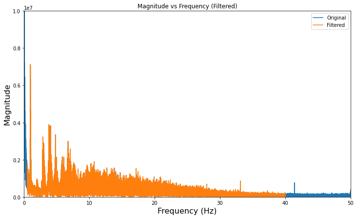

```python
# Plot raw and filtered ECG signal in the frequency domain, frequencies from 0 to 50 Hz
plt.figure(figsize=(12, 7))
plt.plot(freqs, np.abs(dft), label='Original')
plt.plot(filtered_freqs, np.abs(filtered_dft), label='Filtered')
plt.title("Magnitude vs Frequency (Filtered)")
plt.xlabel("Frequency (Hz)", fontsize=16)
plt.ylabel("Magnitude", fontsize=16)
plt.xlim(0, 50)
plt.ylim(0, 1e7)
plt.legend()
plt.show()
```

## Observations:

These first frequencies that are smaller than 0.5 Hz are considered noise, so deleting them is necessary for a good analysis of the signal.

# QRS Detection

- QRS detection using “hamilton” method provided by the “biosppy” package.
- If you do not have this package installed, use the following command to install it !pip install biosppy in the next cell
- For google colab use following command in the cell as well: !pip install biosppy

```python
import biosppy
from biosppy.signals import ecg
```

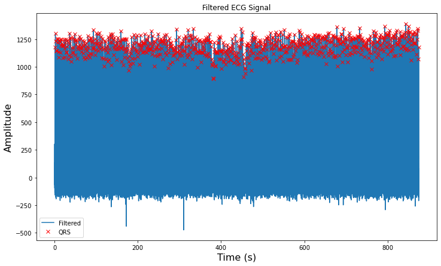

```python
# QRS detection using 'hamilton' method
qrs_hamilton = ecg.hamilton_segmenter(signal=filtered_ecg4, sampling_rate=fs)
qrs_index_hamilton = qrs_hamilton[0]

# Plot the filtered ECG signal and the detected QRS complex
plt.figure(figsize=(12, 7))
plt.plot(seconds_time, filtered_ecg4, label='Filtered')
plt.plot(seconds_time[qrs_index_hamilton], filtered_ecg4[qrs_index_hamilton], 'rx', label='QRS')
plt.title("Filtered ECG Signal")
plt.xlabel("Time (s)", fontsize=16)
plt.ylabel("Amplitude", fontsize=16)
plt.legend()
plt.show()
```

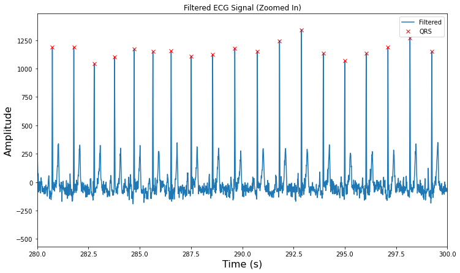

```python
# Plot the filtered ECG signal and the detected QRS complex (zoomed in)
plt.figure(figsize=(12, 7))
plt.plot(seconds_time, filtered_ecg4, label='Filtered')
plt.plot(seconds_time[qrs_index_hamilton], filtered_ecg4[qrs_index_hamilton], 'rx', label='QRS')
plt.title("Filtered ECG Signal (Zoomed In)")
plt.xlabel("Time (s)", fontsize=16)
plt.ylabel("Amplitude", fontsize=16)
plt.xlim(280,300)
plt.legend()
plt.show()
```

## Observations:

When zooming in in the signal, the QRS detection by the Hamilton method seems to work. The crosses indicating the peaks of the qrs complex coincide with the peaks of the ECG signal. This tells us that the method used (Hamilton) has worked correctly, as far as the naked eye can see. In addition, it can be seen how they follow a rhythm, which is what the heart does.